# Number of Lines versus Number of Functions in Different Languages

## Don’t Compare Apples to Oranges

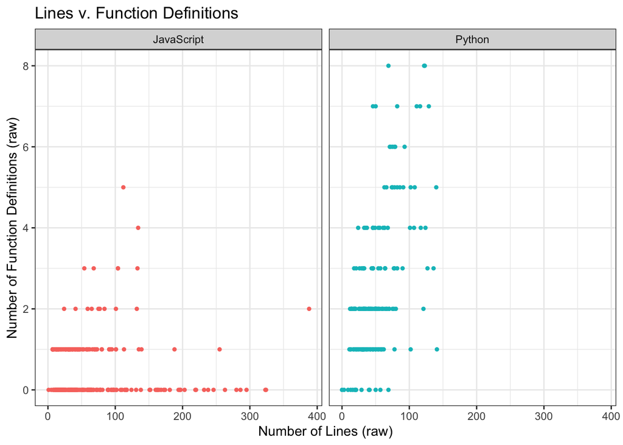

```r
plt = ggplot(data,aes(Lines,FunctionDefs))+
  facet_wrap(~Language)+
  geom_point(aes(colour=Language),size=1, show.legend=FALSE)+
  #geom_vline(xintercept=mean(data$Lines),colour="red",linetype="dashed")+
  #geom_hline(yintercept=mean(data$FunctionDefs),colour="red",linetype="dashed")+
  ggtitle("Lines v. Function Definitions")+
  xlab("Number of Lines (raw)")+
  ylab("Number of Function Definitions (raw)")+

  theme_bw()

plt
```

```r
ggsave("Raw_LinesFunctions.png",plt)

cor(data$Lines[data$Language=="JavaScript"],data$FunctionDefs[data$Language=="JavaScript"])
```

```
## [1] 0.0218202
```

```r
cor(data$Lines[data$Language=="Python"],data$FunctionDefs[data$Language=="Python"])
```

```
## [1] 0.5789447
```

```r
#take a look at the scales between the two languages
data %>%
  group_by(Language) %>%
  summarise(mean(Lines),mean(FunctionDefs), sd(Lines),sd(FunctionDefs))
```

```
## # A tibble: 2 x 5
##   Language   `mean(Lines)` `mean(FunctionDef… `sd(Lines)` `sd(FunctionDefs…
##   <chr>              <dbl>              <dbl>       <dbl>             <dbl>
## 1 JavaScript          62.1              0.476        63.7             0.732
## 2 Python              50.7              2.44         29.6             1.83
```

```r
#we need to normalize in order to more fairly compare
data = data %>%
  group_by(Language) %>%
  mutate(Lines.normed = scale(Lines)) %>%
  mutate(FunctionDefs.normed = scale(FunctionDefs))
```

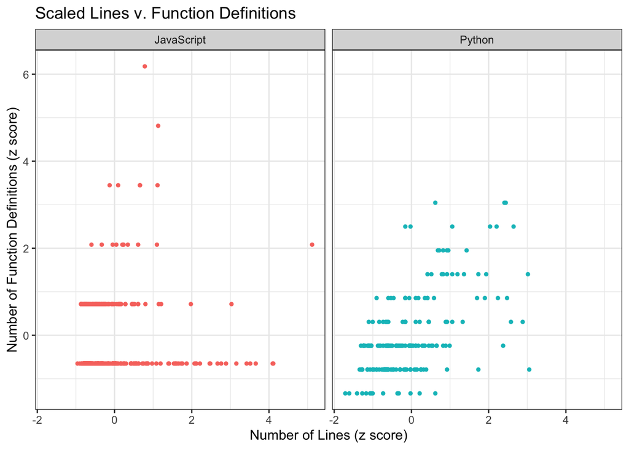

```r
plt = ggplot(data,aes(Lines.normed,FunctionDefs.normed))+
  facet_wrap(~Language)+
  geom_point(aes(colour=Language),size=1, show.legend=FALSE)+
  #geom_vline(xintercept=mean(data$Lines),colour="red",linetype="dashed")+
  #geom_hline(yintercept=mean(data$FunctionDefs),colour="red",linetype="dashed")+
  ggtitle("Scaled Lines v. Function Definitions")+
  xlab("Number of Lines (z score)")+
  ylab("Number of Function Definitions (z score)")+

  theme_bw()

plt
```

```r
#ggsave("lines_and_defs.png",plt)
```

## Sample Bias

You may have some questions about the sample we used. With any problem, we need to think about where our data came from (not just questions that we can ask *about* the data). Problems start in our sample, not in our analysis. This is an important concept to keep in mind when presented with *any* statistic. Is the sample representative? Where did the data come from? Is publicly available data different from what you could obtain from a private source? Is the sample from one group comparable with the sample from the other? In this case, I’ve tried to collect programs that are roughly the same content; introductory Computer Science programs and data structures. Whatever I find may not generalize to the languages as a whole; perhaps in writing out data structures the code is for educational purposes, and looks different from code in practice. Whatever we conclude on this sample might not be representative on a different sample. Not to get too philosophical, but any statistics that we perform are really an exercise in:

> *“How do we know what we know?”*

```r
cor(data$FunctionDefs[data$Language=="JavaScript"],data$Lines[data$Language=="JavaScript"])
```

```
## [1] 0.0218202
```

## Normality Matters

We are all about finding differences, but comparing those differences is a delicate business. We learned that we can’t compare Apples to Oranges, so we **normalized** our data. Sometimes, that’s enough to be able to draw direct comparisons. Once we are on the same scale, we can go ahead and use statistical tests to compare groups. But there’s something else that matters, and that’s whether our data can be represented **parametrically** or not. Don’t worry, it’s not as scary as it sounds. **Parametric** means that the data distribution can be represented using *parameters*, like mean and standard deviation. We learned that the normal distribution can be expressed in terms of mean and standard deviation, and any data that falls **normally** is parametric. But lots of data will *not* fall under a normal distribution. Never fear, the weirdos can be compared too. We use something called **nonparametric testing**. Yep, you guessed it. These tests don’t represent the data with parameters. They tend to use **ranks** instead. For now, just know that in order to compare two samples, we need to make sure we know which tests to use given the normality of those samples.

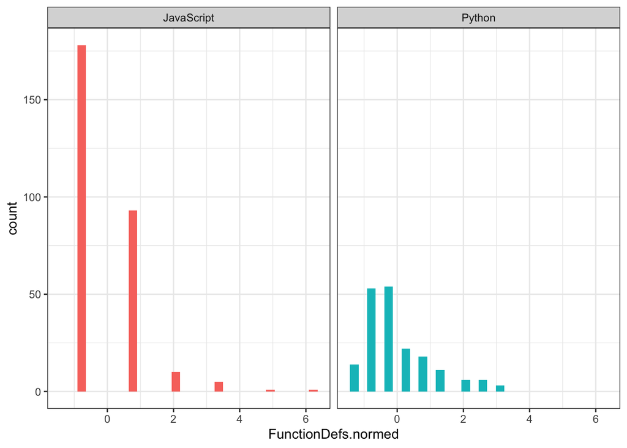

```r
# here we can take a look at the distributions of our normalized (z-scores) data
plt = ggplot(data, aes(FunctionDefs.normed,fill=Language))+
  geom_histogram(show.legend=FALSE)+
  #geom_density()+
  facet_wrap(~Language)+
  theme_bw()
plt
```

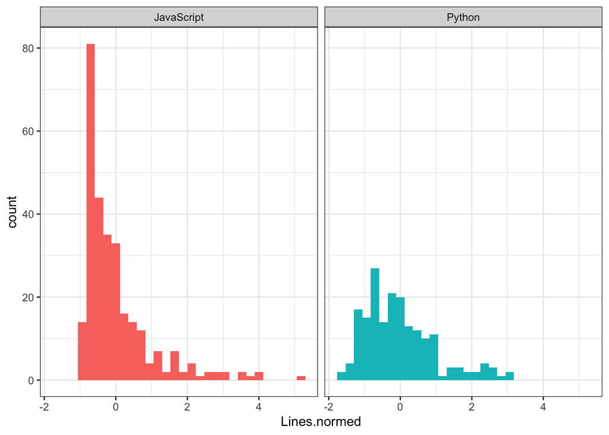

```r
plt = ggplot(data, aes(Lines.normed,fill=Language))+
  geom_histogram(show.legend=FALSE)+
  #geom_density()+
  facet_wrap(~Language)+
  theme_bw()
plt
```

it doesn’t look normal, and that’s pretty obvious. But for less obvious deviation from normality, we use a **Shapiro-Wilk Test**. The test is beginning with the hypothesis that our distribution and a normal distribution **are different**. The test will give back a *W* score and a **p-value**. When *W* is small, it is likely that our distribution is *different from normal*, with probability *p*. If the *p-value* is less than .05, we tend to conclude that our distribution is **not** normal.

[figure not shown]

```r
# Python number of function definitions
shapiro.test(data$FunctionDefs[data$Language=="Python"])
```

```
##
##  Shapiro-Wilk normality test
##
## data:  data$FunctionDefs[data$Language == "Python"]
## W = 0.87633, p-value = 2.871e-11
```

```r
# JavaScript number of function definitions
shapiro.test(data$FunctionDefs[data$Language=="JavaScript"])
```

```
##
##  Shapiro-Wilk normality test
##
## data:  data$FunctionDefs[data$Language == "JavaScript"]
## W = 0.64367, p-value < 2.2e-16
```

```r
# Python number of lines
shapiro.test(data$Lines[data$Language=="Python"])
```

```
##
##  Shapiro-Wilk normality test
##
## data:  data$Lines[data$Language == "Python"]
## W = 0.92613, p-value = 3.962e-08
```

```r
# JavaScript number of lines
shapiro.test(data$Lines[data$Language=="JavaScript"])
```

```
##
##  Shapiro-Wilk normality test
##
## data:  data$Lines[data$Language == "JavaScript"]
## W = 0.75725, p-value < 2.2e-16
```